# AY2025 Homework#1

Pongsun B.

2026-01-28

## 2101-565 Data Analytics and Machine Learning in Transportation Engineering

ชื่อ-นามสกุล: สมรรถพล ลิ้มวุฒิวงศ์

รหัสนิสิต: 6730525021

## Q1: Non-parametric Test (10 คะแนน)

Import ข้อมูลจากไฟล์ Excel ใน Sheet ชื่อ “InsectSpray” ซึ่งอธิบายจำนวนแมลงที่ถูกฆ่าในการทดสอบยาฆ่าแมลง 3 ชนิด และสร้างเป็น object ชื่อ insect_data โดยข้อมูลมีโครงสร้าง ดังนี้

library(ggmosaic)

- `Bugs` เป็นตัวแปรตาม แสดงจำนวนแมลงที่ถูกฆ่า
- `Spray` เป็นข้อมูลแบบ Categorical data แสดงยาฆ่าแมลง 3 ชนิด ได้แก่ C, D และ F

นักวิจัยอยากทราบว่ายาฆ่าแมลง 3 ชนิดนี้มีประสิทธิภาพในการฆ่าแมลงแตกต่างกันหรือไม่

Step 1: เปลี่ยนชุดข้อมูล Spray ให้เป็น factor โดยเปลี่ยน label ของข้อมูล C, D และ F เป็น type_C, type_D และ type_F ตามลำดับ (0.5 คะแนน)

Step 2: ใช้ Shapiro-Wilk test เพื่อทดสอบว่าจำนวนแมลงที่ถูกฆ่าจำแนกตามประเภทของยาฆ่าแมลงมีการกระจายตัวแบบ normal distribution หรือไม่ แสดงค่า p-value ของการทดสอบและสรุปผลการทดสอบสมมติฐานที่ระดับนัยสำคัญ α = 0.05 (1 คะแนน)

Step 3: สร้าง Boxplot เพื่อทดสอบว่ามี outliers ในข้อมูลจำนวนแมลงที่ถูกฆ่าจำแนกตามประเภทของยาฆ่าแมลงหรือไม่ โดย Boxplot ทั้ง 3 รูป แสดงผลตามแนวตั้ง และแสดง outliers เป็นจุดสีแดง (1.5 คะแนน)

Step 4: เขียนสมมติฐานเพื่อทดสอบว่า ยาฆ่าแมลง 3 ชนิดมีประสิทธิภาพในการฆ่าแมลงแตกต่างกันหรือไม่ ระบุค่า p-value ของการทดสอบและสรุปผลการทดสอบสมมติฐานที่ระดับนัยสำคัญ α = 0.05 (2 คะแนน)

Step 5: ทำ post-hoc analysis เพื่อระบุว่า ยาฆ่าแมลงชนิดใด (คู่ใด) ที่มีประสิทธิภาพในการฆ่าแมลงแตกต่างกันอย่างมีนัยสำคัญ ที่ระดับนัยสำคัญ α = 0.05 (2 คะแนน)

Step 6: หากอนุโลมว่าข้อมูลทั้งหมดมีการกระจายตัวแบบ normal distribution จงใช้ analysis of variance (ANOVA) และ Tukey HSD เพื่อทดสอบสมมติฐานใน step 4 และ 5 อีกครั้งและอภิปรายว่าผลการทดสอบทั้ง 2 วิธีให้ข้อสรุปที่แตกต่างกันหรือไม่อย่างไร (3 คะแนน)

=-=-=-=-=-=-=-=-=-=-=-=-=

ตอบคำถามบรรยายที่นี่

Step 4:

H1: ยาฆ่าแมลงทั้ง 3 ชนิดมีประสิทธิภาพในการฆ่าแมลงแตกต่างกัน (อย่างน้อย 1 คู่มีค่ามัธยฐานแตกต่างจากชนิดอื่น)

=-=-=-=-=-=-=-=-=-=-=-=-=

```r
insect_data <- read_excel("AY2025_HW1_Data.xlsx", sheet = "InsectSpray")
str(insect_data)
```

```
## tibble [36 × 2] (S3: tbl_df/tbl/data.frame)
##  $ Bugs : num [1:36] 0 1 7 2 3 1 2 1 3 0 ...
##  $ Spray: chr [1:36] "C" "C" "C" "C" ...
```

```r
# Step 1
insect_data$Spray <- factor(insect_data$Spray, levels = c("C", "D", "F"), labels = c("type_C",
    "type_D", "type_F"))

str(insect_data)
```

```
## tibble [36 × 2] (S3: tbl_df/tbl/data.frame)
##  $ Bugs : num [1:36] 0 1 7 2 3 1 2 1 3 0 ...
##  $ Spray: Factor w/ 3 levels "type_C","type_D",..: 1 1 1 1 1 1 1 1 1 1 ...
```

```r
# Step 2

shapiro_results <- tapply(insect_data$Bugs, insect_data$Spray, shapiro.test)
print(shapiro_results)
```

```
## $type_C
##
##  Shapiro-Wilk normality test
##
## data:  X[[i]]
## W = 0.85907, p-value = 0.04759
##
##
## $type_D
##
##  Shapiro-Wilk normality test
##
## data:  X[[i]]
## W = 0.75063, p-value = 0.002713
##
##
## $type_F
##
##  Shapiro-Wilk normality test
##
## data:  X[[i]]
## W = 0.88475, p-value = 0.1009
```

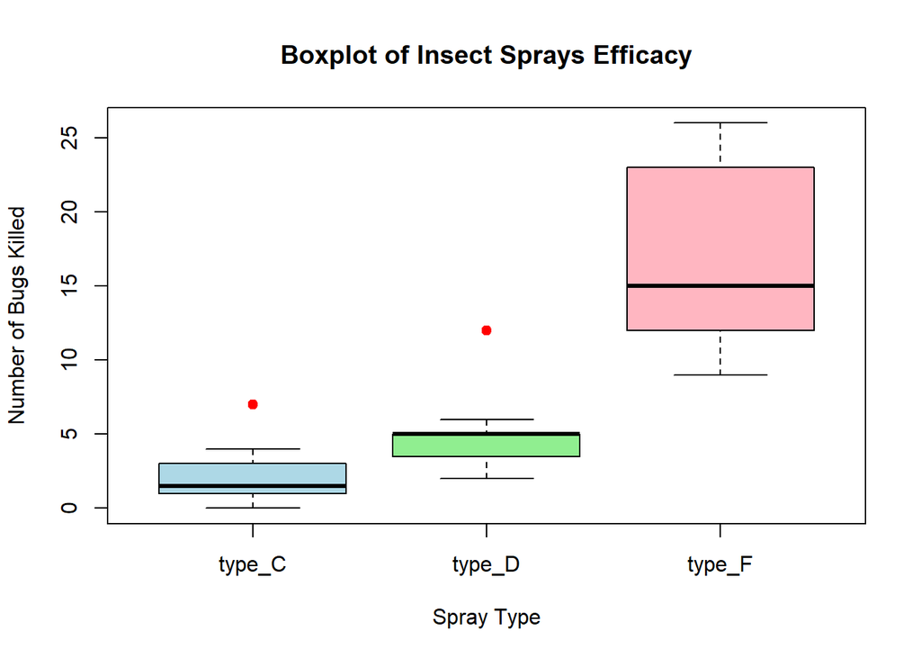

```r
# Step 3

boxplot(Bugs ~ Spray, data = insect_data, main = "Boxplot of Insect Sprays Efficacy",
    xlab = "Spray Type", ylab = "Number of Bugs Killed", col = c("lightblue", "lightgreen",
        "lightpink"), outpch = 19, outcol = "red")
```

```r
# Step 4

kw_test <- kruskal.test(Bugs ~ Spray, data = insect_data)
print(kw_test)
```

```
##
##  Kruskal-Wallis rank sum test
##
## data:  Bugs by Spray
## Kruskal-Wallis chi-squared = 26.866, df = 2, p-value = 1.466e-06
```

```r
# Step 5

posthoc_kw <- pairwise.wilcox.test(insect_data$Bugs, insect_data$Spray, p.adjust.method = "bonferroni")
print(posthoc_kw)
```

```
##
##  Pairwise comparisons using Wilcoxon rank sum test with continuity correction
##
## data:  insect_data$Bugs and insect_data$Spray
##
##        type_C  type_D
## type_D 0.00795 -
## type_F 0.00010 0.00021
##
## P value adjustment method: bonferroni
```

```r
# Step 6

anova_model <- aov(Bugs ~ Spray, data = insect_data)
summary(anova_model)
```

```
##             Df Sum Sq Mean Sq F value   Pr(>F)
## Spray        2 1435.1   717.5   44.13 4.72e-10 ***
## Residuals   33  536.5    16.3
## ---
## Signif. codes:  0 '***' 0.001 '**' 0.01 '*' 0.05 '.' 0.1 ' ' 1
```

```r
tukey_result <- TukeyHSD(anova_model)
print(tukey_result)
```

```
##   Tukey multiple comparisons of means
##     95% family-wise confidence level
##
## Fit: aov(formula = Bugs ~ Spray, data = insect_data)
##
## $Spray
##                    diff       lwr       upr     p adj
## type_D-type_C  2.833333 -1.205821  6.872488 0.2124805
## type_F-type_C 14.583333 10.544179 18.622488 0.0000000
## type_F-type_D 11.750000  7.710846 15.789154 0.0000001
```

## Q2: Test for Nominal Data (10 คะแนน)

ข้อมูลต่อไปนี้เป็นผลสำรวจความชื่นชอบในตัวผู้สมัครชิงตำแหน่งผู้ว่าราชการจังหวัดกรุงเทพมหานครท่านหนึ่ง จากผู้เข้าร่วมรับฟังการแถลงนโยบายของผู้สมัครที่จัดขึ้น 3 ครั้งในเดือนมีนาคม เมษายน และพฤษภาคม 2565 โดยผู้เข้าร่วมการสำรวจทุกคนได้เข้ารับฟังการแถลงนโยบายทั้ง 3 ครั้ง

ให้ Import และสร้างเป็น object ชื่อ survey_data จากไฟล์ Excel ใน Sheet ชื่อ “Survey” โดยข้อมูลมีโครงสร้าง ดังนี้

- `participant` เป็นข้อมูลแบบ character แสดง code ของผู้เข้าร่วมการสำรวจความคิดเห็น
- `MAR` เป็นข้อมูลแบบ numeric แสดงการยอมรับในตัวผู้สมัคร ในเดือนมีนาคม 2565 โดย 0 หมายถึง ไม่ชอบ และ 1 หมายถึง ชอบ
- `APR` เช่นเดียวกับ `MAR` แต่เป็นผลการสำรวจในเดือนเมษายน 2565
- `MAY` เช่นเดียวกับ `MAR` แต่เป็นผลการสำรวจในเดือนพฤษภาคม 2565

Step 1: เปลี่ยนรูปแบบข้อมูล survey_data จากแบบ wide เป็นแบบ long โดยกำหนดให้ names_to = “month” และ values_to = “agreement” (1 คะแนน)

Step 2: เพิ่มคอลัมน์ชื่อ month.F โดยเปลี่ยนชุดข้อมูล month ให้เป็น factor โดยกำหนดให้ลำดับใน factor เรียงตามลำดับ ดังนี้ MAR, APR และ MAY (1 คะแนน)

Step 3: เพิ่มคอลัมน์ชื่อ agreement.F โดยเปลี่ยนชุดข้อมูล agreement ให้เป็น factor โดยเปลี่ยน label ของข้อมูล 1 และ 0 เป็น “plus” และ “minus” ตามลำดับ (1 คะแนน)

Step 4: สร้างตารางแจกแจงความถี่ด้วยคำสั่ง `xtabs` เพื่อนับจำนวนผู้เข้าร่วมรับฟังการแถลงนโยบายของผู้สมัครตามความชื่นชอบในแต่ละเดือน (1 คะแนน)

Step 5: สร้าง Mosaic plot จากตารางแจกแจงความถี่ในขั้นตอนที่ 4 และตั้งชื่อรูปว่า Agreement Proportion by Month (2 คะแนน)

Step 6: สร้างกราฟแท่ง (bar chart) แบบ 100% stack แสดงสัดส่วนของผู้ที่ชื่นชอบและไม่ชื่นชอบในตัวผู้สมัครจำแนกตามรายเดือน และให้ชื่อแกน X ว่า Month แกน Y ว่า Proportion of agreement (%) (2 คะแนน)

**Hint:** ใช้ `scale_y_continuous(labels=scales::percent)` เพื่อแสดงค่าแกน Y เป็นร้อยละ

Step 7: เขียนสมมติฐานและทดสอบว่า สัดส่วนความชื่นชอบในตัวผู้สมัครชิงตำแหน่งผู้ว่าราชการจังหวัดกรุงเทพมหานครท่านนี้มีการเปลี่ยนแปลงอย่างมีนัยสำคัญหรือไม่ในแต่ละเดือน ระบุค่า *p*-value ของการทดสอบและสรุปผลการทดสอบสมมติฐานที่ระดับนัยสำคัญ α = 0.05 (2 คะแนน)

=-=-=-=-=-=-=-=-=-=-=-=-=

ตอบคำถามบรรยายที่นี่

Step 7:

H1:สัดส่วนความชื่นชอบในตัวผู้สมัครชิงตำแหน่งผู้ว่าราชการจังหวัดกรุงเทพมหานครมีการเปลี่ยนแปลงอย่างมีนัยสำคัญในแต่ละเดือน (หรือ มีอย่างน้อย 1 เดือนที่สัดส่วนความชื่นชอบแตกต่างจากเดือนอื่น)

=-=-=-=-=-=-=-=-=-=-=-=-=

```r
survey_data <- read_excel("AY2025_HW1_Data.xlsx", sheet = "Survey")
str(survey_data)
```

```
## tibble [50 × 4] (S3: tbl_df/tbl/data.frame)
##  $ Participant: chr [1:50] "S01" "S02" "S03" "S04" ...
##  $ MAR        : num [1:50] 0 0 0 0 0 0 0 0 0 1 ...
##  $ APR        : num [1:50] 1 1 1 1 0 1 1 1 1 0 ...
##  $ MAY        : num [1:50] 0 1 1 1 1 1 1 1 1 1 ...
```

```r
set.seed(123)
survey_data <- data.frame(participant = paste0("P", 1:20), MAR = sample(c(0, 1),
    20, replace = TRUE), APR = sample(c(0, 1), 20, replace = TRUE), MAY = sample(c(0,
    1), 20, replace = TRUE))

# Step 1

survey_long <- survey_data %>%
    pivot_longer(cols = c(MAR, APR, MAY), names_to = "month", values_to = "agreement")

# Step 2

survey_long$month.F <- factor(survey_long$month, levels = c("MAR", "APR", "MAY"))

# Step 3

survey_long$agreement.F <- factor(survey_long$agreement, levels = c(0, 1), labels = c("minus",
    "plus"))

str(survey_long)
```

```
## tibble [60 × 5] (S3: tbl_df/tbl/data.frame)
##  $ participant: chr [1:60] "P1" "P1" "P1" "P2" ...
##  $ month      : chr [1:60] "MAR" "APR" "MAY" "MAR" ...
##  $ agreement  : num [1:60] 0 0 0 0 1 1 0 0 1 1 ...
##  $ month.F    : Factor w/ 3 levels "MAR","APR","MAY": 1 2 3 1 2 3 1 2 3 1 ...
##  $ agreement.F: Factor w/ 2 levels "minus","plus": 1 1 1 1 2 2 1 1 2 2 ...
```

```r
# Step 4

freq_table <- xtabs(~agreement.F + month.F, data = survey_long)
print(freq_table)
```

```
##            month.F
## agreement.F MAR APR MAY
##       minus  11  12  13
##       plus    9   8   7
```

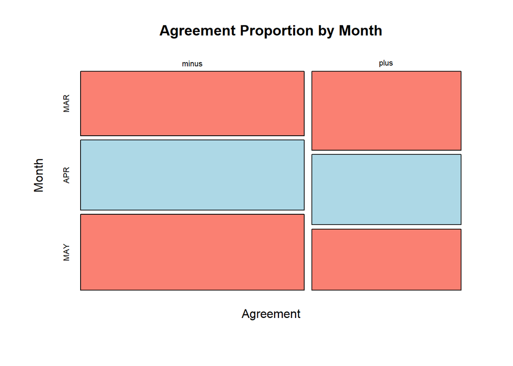

```r
# Step 5

mosaicplot(freq_table, main = "Agreement Proportion by Month", col = c("salmon",
    "lightblue"), xlab = "Agreement", ylab = "Month")
```

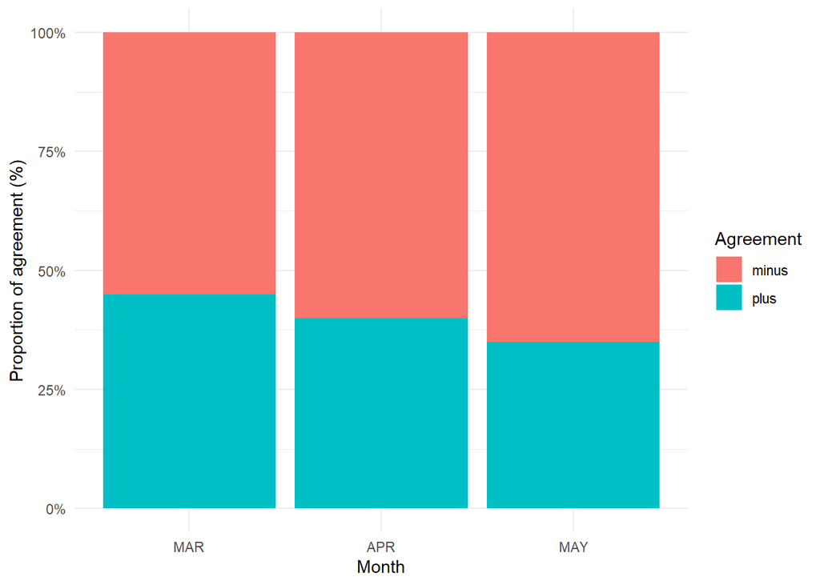

```r
# Step 6
ggplot(survey_long, aes(x = month.F, fill = agreement.F)) + geom_bar(position = "fill") +
    scale_y_continuous(labels = scales::percent, name = "Proportion of agreement (%)") +
    labs(x = "Month", fill = "Agreement") + theme_minimal()
```

```r
# Step 7
test_result <- friedman.test(agreement ~ month.F | participant, data = survey_long)
print(test_result)
```

```
##
##  Friedman rank sum test
##
## data:  agreement and month.F and participant
## Friedman chi-squared = 0.4, df = 2, p-value = 0.8187
```

End-of-File  
2026-01-28